# **FLife**

Example of Conditioning an Operating Model

03 September, 2019

```r
library(ggplotFL)
library(plyr)
library(reshape)
library(FLBRP)
library(FLife)
```

## Install FLR packages

To follow this tutorial a number of packages need to be installed, either from CRAN or from www.flr-project.org where variety of packages and [tutorials](https://www.flr-project.org/doc/) are available.

```r
install.packages(c("FLCore","FLFishery","FLasher","FLBRP","mpb","FLife"),
             repos="http://flr-project.org/R")
```

`devtools` also needs to be installed and loaded so that the `mydas` package can be installed from the GitHub repository.

```r
install.packages("devtools",dependencies=TRUE)
```

```r
library(devtools)

devtools::install_github("lauriekell/mydas-pkg")
```

## Load Libraries

```r
library(plyr)
library(reshape)
library(ggplot2)
```

```r
library(FLCore)
library(FLasher)
library(FLBRP)
library(FLife)
library(mydas)
```

### Life history parameters

Get fishbase data

```r
load(url("https://github.com//fishnets//fishnets//blob//master//data//fishbase-web//fishbase-web.RData?raw=True"))
```

Select turbot as a case study

```r
lh=subset(fb,species=="Psetta maxima")

names(lh)[c(14,17)] = c("l50","a50")
lh=lh[,c("linf","k","t0","a","b","a50","l50")]

head(lh)
```

```
     linf    k    t0      a    b a50  l50
3697 53.9 0.27 -0.12     NA   NA  NA   NA
3698 81.5 0.21 -0.48     NA   NA  NA   NA
3699 54.6 0.31 -0.12 0.0189 2.93   4 49.0
3700 78.6 0.19 -0.80     NA   NA  NA   NA
3701 54.4 0.23 -0.22 0.0219 2.92  NA 37.5
3702 73.6 0.28  0.08 0.0189 2.93   4 49.0
```

Get the means and create an `FLPar` object

```r
lh=apply(lh,2,mean,na.rm=T)
lh=FLPar(lh)
```

Values can be replace with any [better estimates](https://www.researchgate.net/publication/236650425_Ecological_and_economic_trade-offs_in_the_management_of_mixed_fisheries_A_case_study_of_spawning_closures_in_flatfish_fisheries) that may be available.

`lhPar` fills in missing values using life history theory, while quantities like selection-at-age are set using defaults, in this case set to be the same as maturity-at-age.

```r
par=lhPar(lh)
par
```

```
An object of class "FLPar"
params
     linf         k        t0         a         b     ato95       a50
  58.6840    0.2868   -0.3120    0.0204    2.9250    1.0000    4.0000
     asym        bg        m1        m2        a1        sl        sr
   1.0000    2.9250  175.0288   -1.6100    5.0000    1.0000 5000.0000
        s         v       l50
   0.9000 1000.0000   43.2500
units:  cm
```

The parameters are then used by `lhEql` to simulate the equilibrium dynamics by combining the spawner/yield per recruit relationships with a stock recruitment relationship, by creating an [`FLBRP` object](https://www.flr-project.org/doc/Reference_points_for_fisheries_management_with_FLBRP.html)

```r
eq=lhEql(par)
```

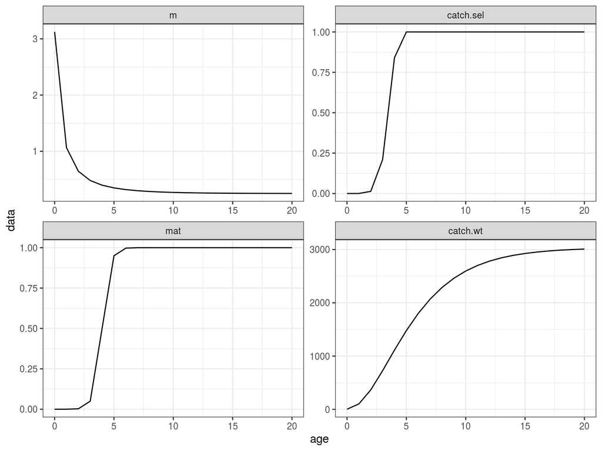

**Figure 1** Vectors of m, selection pattern, maturity and weight-at-age.

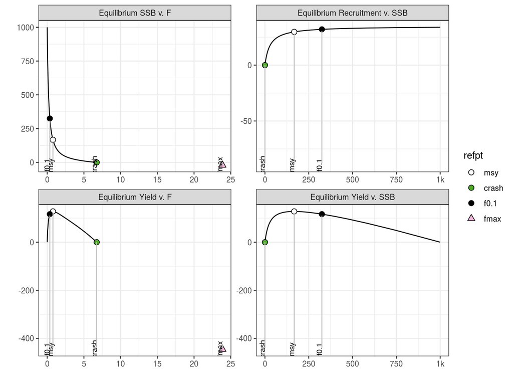

```r
plot(eq)
```

**Figure 2** Expected, equilibrium, dynamics and reference points.

To model time series the FLBRP object created by lhEql is coerced to an FLStock object and then [projected forward](https://www.flr-project.org/doc/Forecasting_on_the_Medium_Term_for_advice_using_FLasher.html)

Simulate a time series that represents a stock that was originally lightly exploited, then effort is increased until the stock is overfished and then fishing pressure was reduced to recover the stock biomass to BMSY.

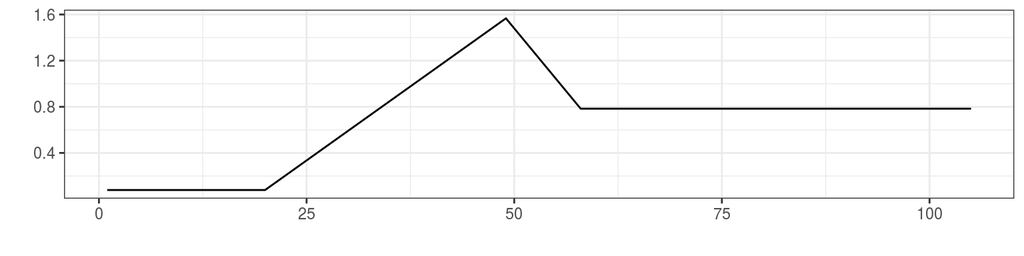

```r
fbar(eq)=refpts(eq)["msy","harvest"]%*%FLQuant(c(rep(.1,19),
                                              seq(.1,2,length.out = 30)[-30],
                                              seq(2,1.0,length.out = 10),
                                              rep(1.0,61)))[,1:105]
plot(fbar(eq))
```

Coercing the FLBRP object into an FLStock

```r
om=as(eq,"FLStock")
```

Call `fwd()` with the stock, the target F and a stock recruitment relationship

```r
om=fwd(om,fbar=fbar(om)[,-1], sr=eq)
```

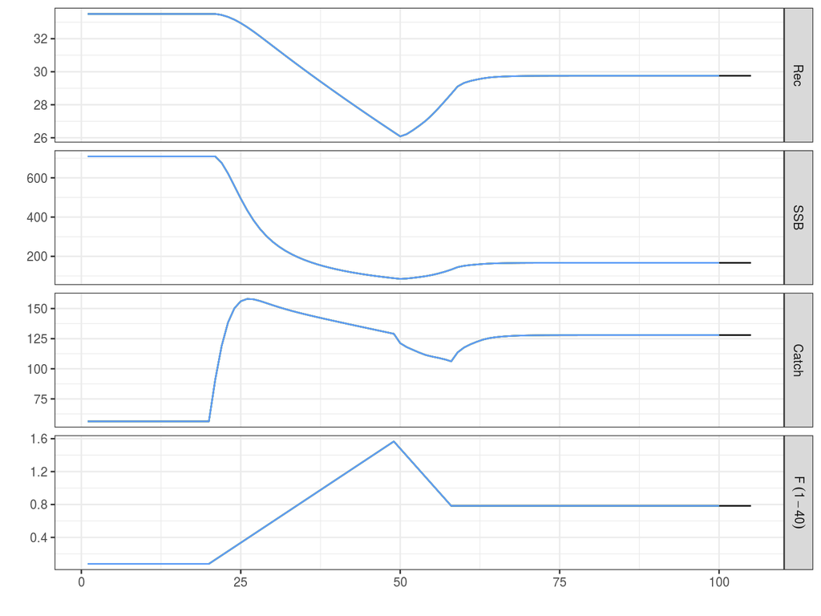

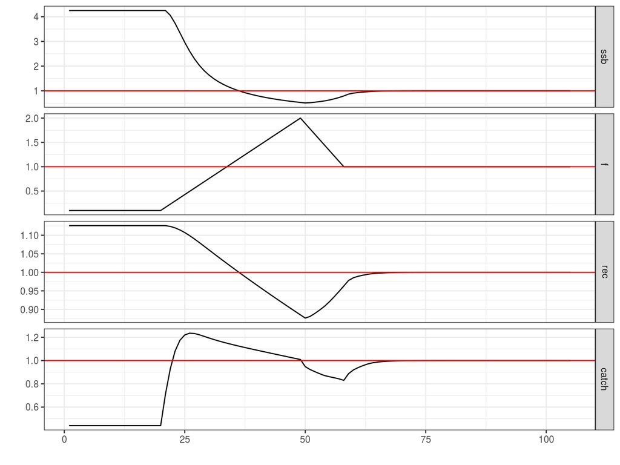

```r
plot(FLQuants(om,
          "ssb" = function(x) ssb(x)%/%refpts( eq)["msy","ssb"],
          "f" =   function(x) fbar(x)%/%refpts(eq)["msy","harvest"],
          "rec" = function(x) rec(x)%/%refpts( eq)["msy","rec"],
          "catch"=function(x) landings(x)%/%refpts(eq)["msy","yield"])) +
  geom_hline(aes(yintercept=1),col="red")
```

**Figure 4** Time series relative to MSY benchmarks.

### Stochasticity

Add recruitment variability into add the residuals argument, e.g. for 100 Monte Carlo simulations with a CV of 0.3

```r
nits=100

srDev=rlnoise(nits, rec(om) %=% 0, 0.3)

om=propagate(om,nits)

om=fwd(om,fbar=fbar(om)[,-1], sr=eq, residuals=srDev)
```

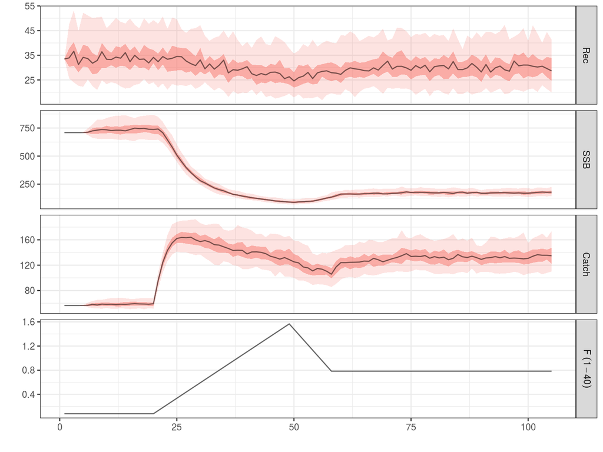

```r
plot(om)
```

**Figure 5** Simulate a stock with increasing F

## Software Versions

- R version 3.6.1 (2019-07-05)
- FLCore: 2.6.13
- FLPKG:
- **Compiled**: Tue Sep 3 11:27:21 2019
- **Git Hash**: 2c7ce1c

## Author information

**Laurence KELL**. laurie@seaplusplus.co.uk